# Cushny and Peeble’s Data

coop711

2015년 3월 26일

### Data Management

- R-base에서 제공하고 있는 sleep data 는 long form data frame 으로 주어져 있음.

```r
sleep
```

```
##    extra group ID
## 1    0.7     1  1
## 2   -1.6     1  2
## 3   -0.2     1  3
## 4   -1.2     1  4
## 5   -0.1     1  5
## 6    3.4     1  6
## 7    3.7     1  7
## 8    0.8     1  8
## 9    0.0     1  9
## 10   2.0     1 10
## 11   1.9     2  1
## 12   0.8     2  2
## 13   1.1     2  3
## 14   0.1     2  4
## 15  -0.1     2  5
## 16   4.4     2  6
## 17   5.5     2  7
## 18   1.6     2  8
## 19   4.6     2  9
## 20   3.4     2 10
```

```r
str(sleep)
```

```
## 'data.frame':    20 obs. of  3 variables:
##  $ extra: num  0.7 -1.6 -0.2 -1.2 -0.1 3.4 3.7 0.8 0 2 ...
##  $ group: Factor w/ 2 levels "1","2": 1 1 1 1 1 1 1 1 1 1 ...
##  $ ID   : Factor w/ 10 levels "1","2","3","4",..: 1 2 3 4 5 6 7 8 9 10 ...
```

- long form을 wide form으로 변환하고, 각각의 경우에 적절한 t-test를 시도해 볼 것임. 먼저 wide form 으로 변환하는 작업은 결국 data frame을 새로 구성하는 것일 뿐이므로 다음으로 완료됨.

```r
sleep.wide<-data.frame(A=sleep[sleep$group==1, 1], B=sleep[sleep$group==2, 1])
sleep.wide
```

```
##       A    B
## 1   0.7  1.9
## 2  -1.6  0.8
## 3  -0.2  1.1
## 4  -1.2  0.1
## 5  -0.1 -0.1
## 6   3.4  4.4
## 7   3.7  5.5
## 8   0.8  1.6
## 9   0.0  4.6
## 10  2.0  3.4
```

## One Sample T test

- long form 에서 각 수면제의 효과가 없다는 가설을 t-test 하려면

```r
t.test(sleep$extra[sleep$group==1], alternative="greater")
```

```
##
##  One Sample t-test
##
## data:  sleep$extra[sleep$group == 1]
## t = 1.3257, df = 9, p-value = 0.1088
## alternative hypothesis: true mean is greater than 0
## 95 percent confidence interval:
##  -0.2870553        Inf
## sample estimates:
## mean of x
##      0.75
```

```r
t.test(sleep$extra[sleep$group==2], alternative="greater")
```

```
##
##  One Sample t-test
##
## data:  sleep$extra[sleep$group == 2]
## t = 3.6799, df = 9, p-value = 0.002538
## alternative hypothesis: true mean is greater than 0
## 95 percent confidence interval:
##  1.169334      Inf
## sample estimates:
## mean of x
##      2.33
```

- 둘을 단번에 수행하려면 tapply()를 이용하여

```r
tapply(sleep$extra, sleep$group, t.test, alternative="greater")
```

```
## $`1`
##
##  One Sample t-test
##
## data:  X[[i]]
## t = 1.3257, df = 9, p-value = 0.1088
## alternative hypothesis: true mean is greater than 0
## 95 percent confidence interval:
##  -0.2870553        Inf
## sample estimates:
## mean of x
##      0.75
##
##
## $`2`
##
##  One Sample t-test
##
## data:  X[[i]]
## t = 3.6799, df = 9, p-value = 0.002538
## alternative hypothesis: true mean is greater than 0
## 95 percent confidence interval:
##  1.169334      Inf
## sample estimates:
## mean of x
##      2.33
```

- 두 수면제 간의 효과에 차이가 없다는 가설을 검증하려면, paired 임을 유념하여야 함.

```r
t.test(sleep$extra[sleep$group==1], sleep$extra[sleep$group==2], paired=T)
```

```
##
##  Paired t-test
##
## data:  sleep$extra[sleep$group == 1] and sleep$extra[sleep$group == 2]
## t = -4.0621, df = 9, p-value = 0.002833
## alternative hypothesis: true difference in means is not equal to 0
## 95 percent confidence interval:
##  -2.4598858 -0.7001142
## sample estimates:
## mean of the differences
##                   -1.58
```

- formula 형식을 빌리면 다음과 같이 비교적 간결하게 기술할 수 있음.

```r
t.test(extra~group, data=sleep, paired=T)
```

```
##
##  Paired t-test
##
## data:  extra by group
## t = -4.0621, df = 9, p-value = 0.002833
## alternative hypothesis: true difference in means is not equal to 0
## 95 percent confidence interval:
##  -2.4598858 -0.7001142
## sample estimates:
## mean of the differences
##                   -1.58
```

- 두 수면제의 효과를 boxplot을 그려 비교하면(산점도를 그려 비교하려면 어떻게?)

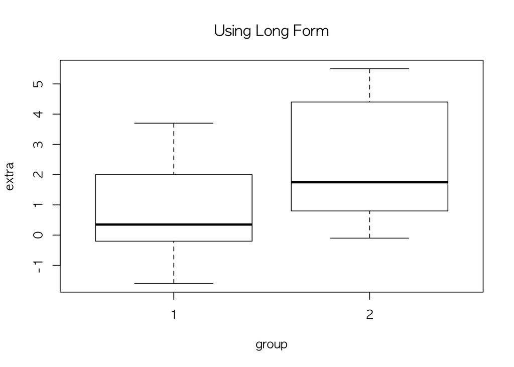

```r
plot(extra~group, data=sleep, main="Using Long Form")
```

- wide form 으로 같은 작업을 수행하면

```r
attach(sleep.wide)
t.test(A, alternative="greater")
```

```
##
##  One Sample t-test
##
## data:  A
## t = 1.3257, df = 9, p-value = 0.1088
## alternative hypothesis: true mean is greater than 0
## 95 percent confidence interval:
##  -0.2870553        Inf
## sample estimates:
## mean of x
##      0.75
```

```r
t.test(B, alternative="greater")
```

```
##
##  One Sample t-test
##
## data:  B
## t = 3.6799, df = 9, p-value = 0.002538
## alternative hypothesis: true mean is greater than 0
## 95 percent confidence interval:
##  1.169334      Inf
## sample estimates:
## mean of x
##      2.33
```

- apply() 를 이용해서 한번에 수행하면

```r
apply(sleep.wide, 2, t.test, alternative="greater")
```

```
## $A
##
##  One Sample t-test
##
## data:  newX[, i]
## t = 1.3257, df = 9, p-value = 0.1088
## alternative hypothesis: true mean is greater than 0
## 95 percent confidence interval:
##  -0.2870553        Inf
## sample estimates:
## mean of x
##      0.75
##
##
## $B
##
##  One Sample t-test
##
## data:  newX[, i]
## t = 3.6799, df = 9, p-value = 0.002538
## alternative hypothesis: true mean is greater than 0
## 95 percent confidence interval:
##  1.169334      Inf
## sample estimates:
## mean of x
##      2.33
```

- 두 수면제 간의 효과 차이를 검증하려면

```r
t.test(A, B, paired=T)
```

```
##
##  Paired t-test
##
## data:  A and B
## t = -4.0621, df = 9, p-value = 0.002833
## alternative hypothesis: true difference in means is not equal to 0
## 95 percent confidence interval:
##  -2.4598858 -0.7001142
## sample estimates:
## mean of the differences
##                   -1.58
```

- 각각의 효과를 산점도를 그려 비교하면

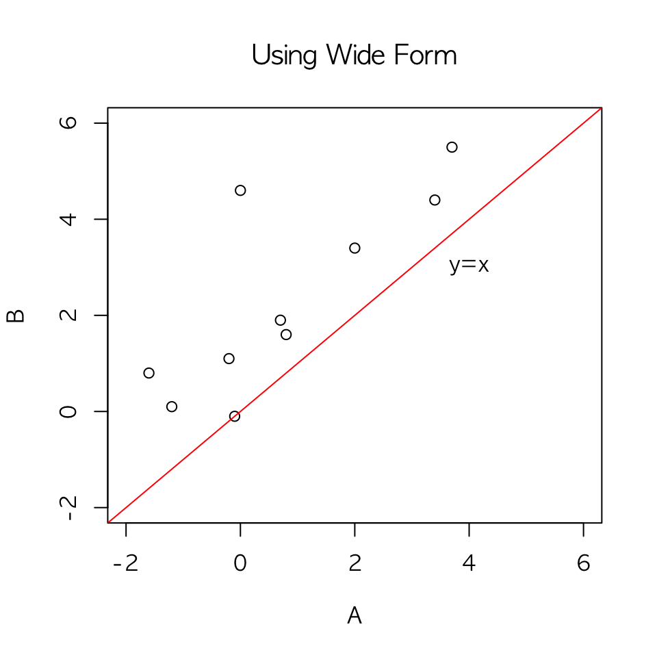

```r
plot(A, B, main="Using Wide Form", xlim=c(-2,6), ylim=c(-2,6))
abline(a=0, b=1, col="red")
text(x=4, y=3, labels="y=x")
```

```r
cor(A, B)
```

```
## [1] 0.7951702
```

- 정규성에 대한 검증은 각자 수행해 볼 것.

```r
# install.packages("nortest", repos = "https://cran.rstudio.com")
library(nortest)
apply(sleep.wide, 2, ad.test)
```

```
## $A
##
##  Anderson-Darling normality test
##
## data:  newX[, i]
## A = 0.34691, p-value = 0.4019
##
##
## $B
##
##  Anderson-Darling normality test
##
## data:  newX[, i]
## A = 0.35716, p-value = 0.3785
```

### Dot plot Comparison

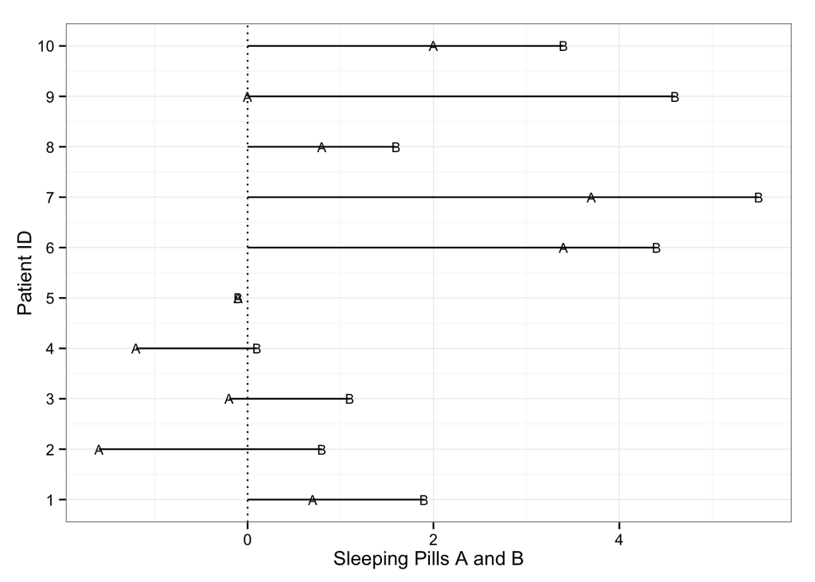

```r
library(ggplot2)
library(grid)
g1 <- ggplot(data.frame(A, B)) + theme_bw()
# g2 <- g1 + geom_segment(aes(x = B, y = reorder(1:10, A), xend = A, yend = reorder(1:10, A)), arrow = arrow(length = unit(0.08, "inches"), ends = "first", type = "open"), linetype = 1)
# g3 <- g2 + xlab("Sleeping Pills A and B") + ylab("Hours Sleep")
g2 <- g1 + geom_point(aes(x = A, y = 1:10), shape = "A", size = 3)
g3 <- g2 + geom_point(aes(x = B, y = 1:10), shape = "B", size = 3)
g4 <- g3 + geom_segment(aes(x = ifelse(A >=0, 0, B), y = 1:10, xend = ifelse(A >= 0, B, A), yend = 1:10))
g5 <- g4 + geom_vline(xintercept = 0, linetype = 3)
g6 <- g5 + scale_y_continuous(name = "Patient ID", breaks = 1:10, labels = 1:10)
g7 <- g6 + scale_x_continuous(name = "Sleeping Pills A and B")
g7
```

- 작업 디렉토리 정리

```r
save(file="sleep.rda", "sleep.wide")
detach()
```